# Reproducible Research: Peer Assessment 1

## Imputing missing values

1. Calculate and report the total number of missing values in the dataset (i.e. the total number of rows with NAs)

```r
# ----- Imputting missing values -----
stepsNa <- mean(is.na(data$steps)) # (1) percentage of missing(NA) values in the dataset
print(stepsNa * 100)
```

```
## [1] 13.11475
```

2. Devise a strategy for filling in all of the missing values in the dataset. The strategy does not need to be sophisticated. For example, you could use the mean/median for that day, or the mean for that 5-minute interval, etc.

There are only NA values in the steps observation. The plan is to create a new data frame and replace the NA’s values with the mean of steps.

3. Create a new dataset that is equal to the original dataset but with the missing data filled in.

```r
# ----- Create dataset with mean steps filled in for NA values -----
data2 <- data # (3)
meanSteps <- as.integer(mean(data$steps, na.rm = TRUE))
data2$steps[which(is.na(data2$steps))] <- meanSteps
```

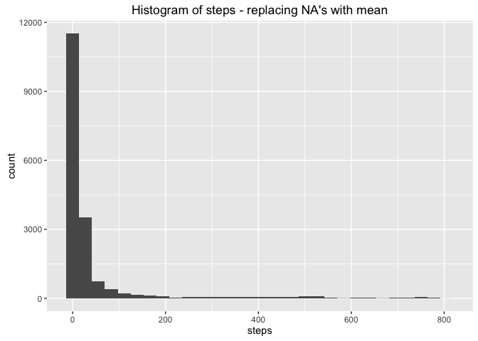

```r
plot <- ggplot(data2, aes(steps))
plot + geom_histogram() + ggtitle("Histogram of steps - replacing NA's with mean")
```

```r
print(summary(data2$steps))
```

```
##    Min. 1st Qu.  Median    Mean 3rd Qu.    Max.
##    0.00    0.00    0.00   37.33   37.00  806.00
```

## Are there differences in activity patterns between weekdays and weekends?

1. Create a new factor variable in the dataset with two levels – “weekday” and “weekend” indicating whether a given date is a weekday or weekend day.

```r
data2$date <- as.Date(data2$date, "%Y-%m-%d")
data2$daysWk <- weekdays(data2$date)
data2$daysWk <- ifelse(data2$daysWk == "Saturday" | data2$daysWk == "Sunday", "Weekend", "Weekday")
```

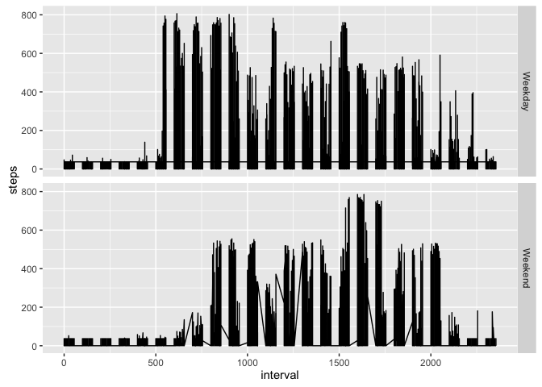

```r
ggplot(data2, aes(interval, steps)) + facet_grid(daysWk ~ .) + geom_line()
```